# ANÁLISE BIBLIOMÉTRICA DE GESTÃO ESPORTIVA

# Results

## Conceptual Structure Analysis

Como fazer a análise: • Os temas no quadrante superior direito são bem desenvolvidos e importantes para a estruturação de um campo de pesquisa. Eles são conhecidos como temas motores da especialidade, pois apresentam forte centralidade e alta densidade. A colocação de temas nesse quadrante implica que eles estejam relacionados externamente a conceitos aplicáveis a outros temas que estão conceitualmente intimamente relacionados.

• Os temas no quadrante superior esquerdo desenvolveram laços internos bem desenvolvidos, mas laços externos sem importância e, portanto, são de importância apenas marginal para o campo. Esses temas são muito especializados e de caráter periférico.

• Os temas no quadrante inferior esquerdo são pouco desenvolvidos e marginais. Os temas desse quadrante têm baixa densidade e baixa centralidade, representando principalmente temas emergentes ou desaparecendo.

• Os temas no quadrante inferior direito são importantes para um campo de pesquisa, mas não são desenvolvidos. Portanto, esse quadrante agrupa temas transversais e gerais, básicos.

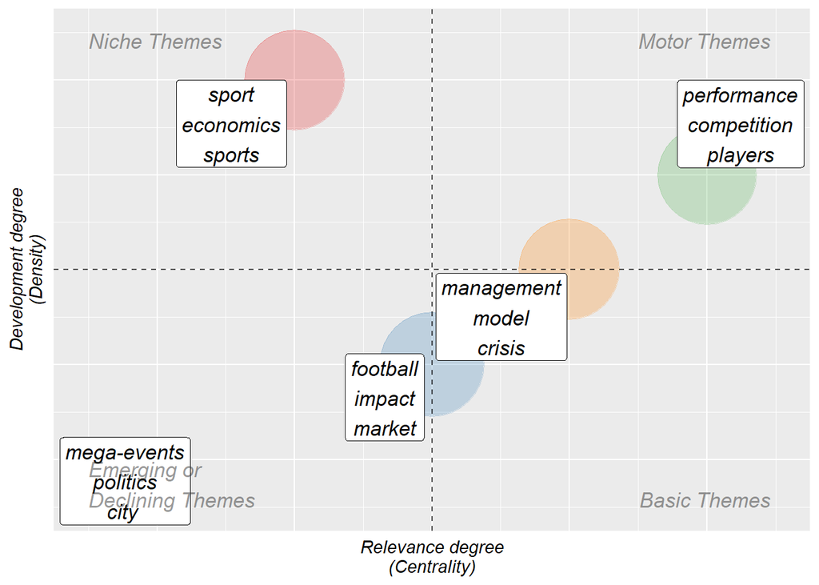

Figure 4.3 – Thematic Map

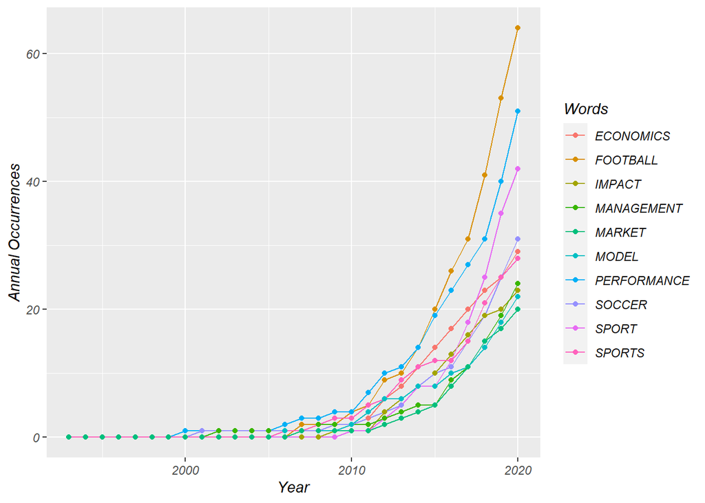

Figure 4.4 – Word growth

## Authors Analysis

Em primeiro lugar, para se ter uma visão geral da produtividades dos autores neste campo de estudo testou-se o ajuste a lei de lotka.

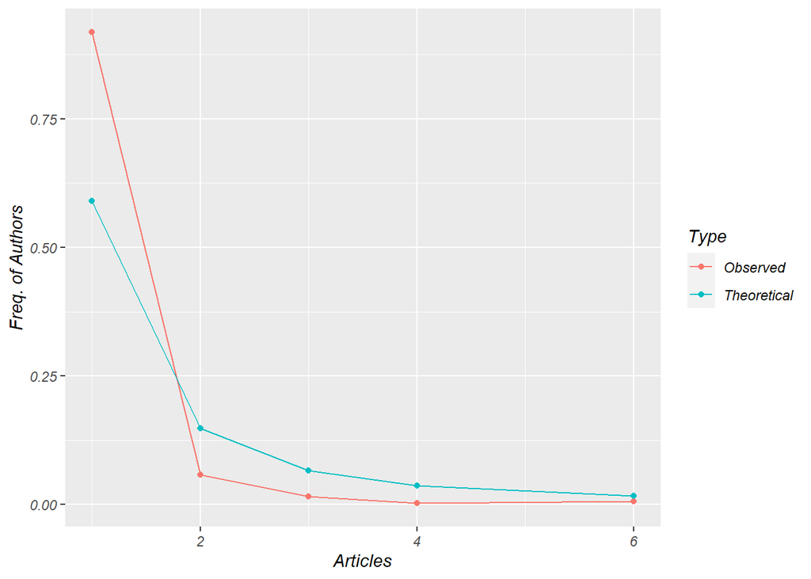

Figure 4.5 – Scientific Productivity

A partir da aplicação do teste de duas amostras de Kolmogorov-Smirnoff calculou-se um p-valor da ordem de 0,15, atestando que não há diferença significativa entre as distribuições de Lotka observada e teórica.

| Authors | H_Index | G_Index | M_Index | Documents | Documents_fractionalized | Local Citations |
| --- | --- | --- | --- | --- | --- | --- |
| BARAJAS A | 4 | 6 | 0.33 | 6 | 2.33 | 28 |
| BREUER C | 5 | 6 | 0.62 | 6 | 2.67 | 14 |
| DIMITROPOULOS P | 5 | 6 | 0.45 | 6 | 3.17 | 24 |
| MORROW S | 5 | 6 | 0.33 | 6 | 2.73 | 4 |
| PLUMLEY D | 4 | 6 | 0.57 | 6 | 1.87 | 5 |
| WILSON R | 4 | 6 | 0.50 | 6 | 1.62 | 3 |
| ANDREFF W | 3 | 4 | 0.33 | 4 | 2.67 | 1 |
| SCELLES N | 4 | 4 | 0.67 | 4 | 1.07 | 5 |
| ANAGNOSTOPOULOS C | 3 | 3 | 0.50 | 3 | 0.92 | 1 |
| CARLSSON-WALL M | 2 | 3 | 0.33 | 3 | 0.83 | 6 |

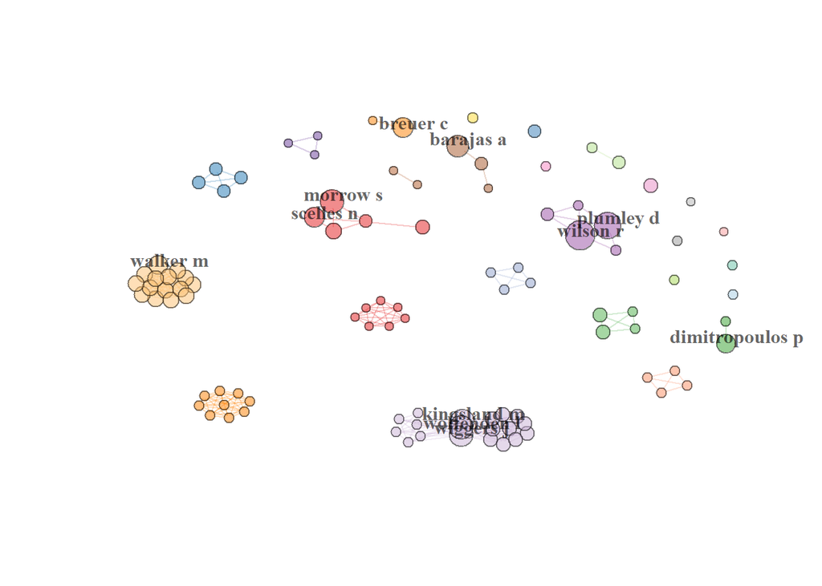

Figure 4.6 – Authors Collaboration

## Documents Analysis

| Papers | DOI | Year | Local Citations | Global Citations |
| --- | --- | --- | --- | --- |
| BARAJAS A, 2010, INT J SPORT FINANC |  | 2010 | 21 | 55 |
| STORM RK, 2012, EUR SPORT MANAG Q | 10.1080/16184742.2012.670660 | 2012 | 20 | 53 |
| FRANCK E, 2014, INT J SPORT FINANC |  | 2014 | 18 | 39 |
| SZYMANSKI S, 2014, INT J SPORT FINANC |  | 2014 | 11 | 20 |
| MADDEN P, 2015, J SPORT ECON | 10.1177/1527002512465759 | 2015 | 9 | 27 |
| DIMITROPOULOS P, 2016, EUR SPORT MANAG Q | 10.1080/16184742.2016.1164213 | 2016 | 9 | 24 |
| SASS M, 2016, J SPORT ECON | 10.1177/1527002514526412 | 2016 | 9 | 25 |
| DIMITROPOULOS PE, 2012, INT J SPORT FINANC |  | 2012 | 8 | 27 |
| DIMITROPOULOS P, 2011, EUR SPORT MANAG Q | 10.1080/16184742.2011.624108 | 2011 | 7 | 20 |
| ASCARI G, 2007, J SPORT ECON | 10.1177/1527002506292582 | 2007 | 6 | 23 |

Mapa historigrafico:

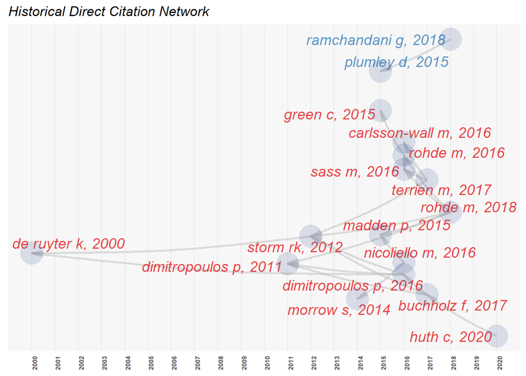

Figure 4.7 – Historiograph

## Sources Analysis

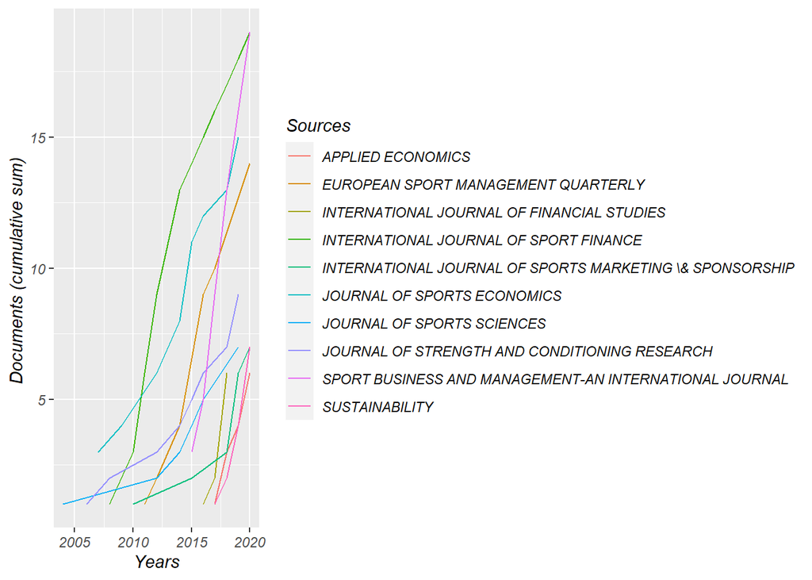

Figure 4.8 – Sources Dynamics

| Sources | H_Index | G_Index | M_Index | Documents |
| --- | --- | --- | --- | --- |
| INTERNATIONAL JOURNAL OF SPORT FINANCE | 10 | 17 | 0.71 | 19 |
| SPORT BUSINESS AND MANAGEMENT-AN INTERNATIONAL JOURNAL | 6 | 7 | 0.86 | 19 |
| JOURNAL OF SPORTS ECONOMICS | 6 | 11 | 0.40 | 15 |
| EUROPEAN SPORT MANAGEMENT QUARTERLY | 9 | 13 | 0.82 | 14 |
| JOURNAL OF STRENGTH AND CONDITIONING RESEARCH | 5 | 9 | 0.31 | 9 |
| INTERNATIONAL JOURNAL OF SPORTS MARKETING & SPONSORSHIP | 3 | 4 | 0.25 | 7 |
| JOURNAL OF SPORTS SCIENCES | 5 | 7 | 0.28 | 7 |
| SUSTAINABILITY | 3 | 5 | 0.60 | 7 |
| APPLIED ECONOMICS | 2 | 3 | 0.40 | 6 |
| INTERNATIONAL JOURNAL OF FINANCIAL STUDIES | 4 | 6 | 0.67 | 6 |

## Affiliation Analysis

| Affiliations | Documents |
| --- | --- |
| SHEFFIELD HALLAM UNIV | 20 |
| UNIV VIGO | 18 |
| GERMAN SPORT UNIV COLOGNE | 16 |
| UNIV MICHIGAN | 13 |
| UNIV STIRLING | 13 |
| UNIV PELOPONNESE | 12 |
| COVENTRY UNIV | 8 |
| LIVERPOOL JOHN MOORES UNIV | 8 |
| MOLDE UNIV COLL | 8 |
| UNIV LONDON | 8 |

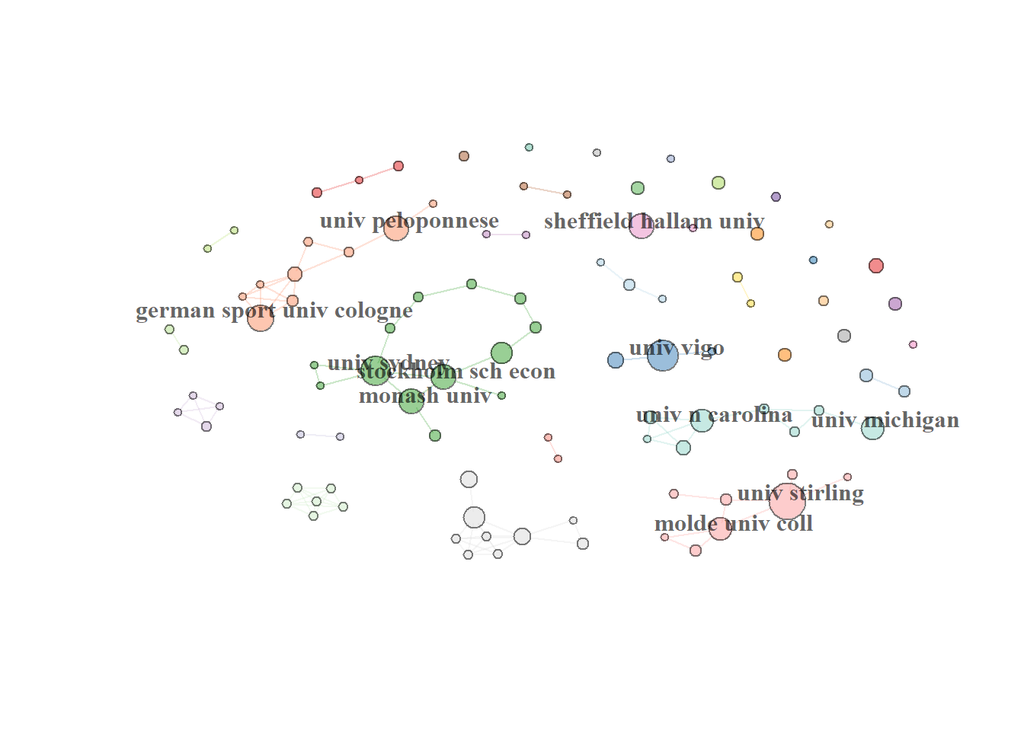

Figure 4.9 – Affiliations Collaboration Network

## Countries Analysis

| Countries | Documents |
| --- | --- |
| USA | 90 |
| UNITED KINGDOM | 57 |
| GERMANY | 41 |
| AUSTRALIA | 26 |
| SPAIN | 23 |
| ITALY | 13 |
| FRANCE | 9 |
| GREECE | 9 |
| NORWAY | 9 |
| CANADA | 6 |

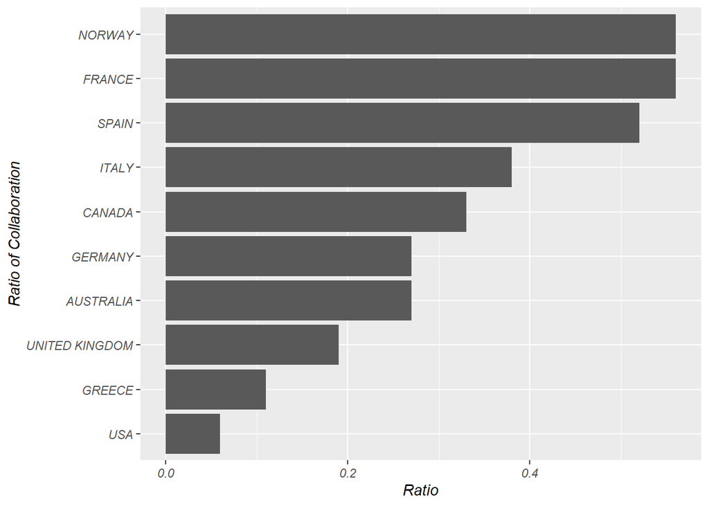

Figure 4.10 – Countries Collaboration

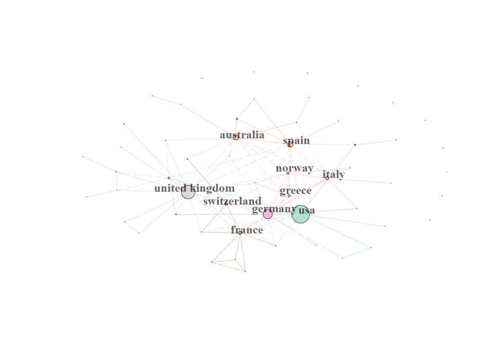